# Case_Study_Group_07

2025-03-17

# Inhaltsverzeichnis

- Importieren der Daten
- Datenaufbereitung
- Erstellen des finalen Datensatzes
- Auswertung
- Ergebnis

# Importieren der Daten

Die Importfunktion hängt vom Format der gegebenen Datensätze ab. Es wird empfohlen, die initiale Importfunktion von RStudio zu nutzen, um die Daten effizient einzulesen.  
Aus dem gegebenen Ordner “Data” werden die relevanten Dateien für die Analyse importiert:

-**Einzelteil, Komponente und Zulassungen:** Alle Dateien aus diesen Unterordnern werden vollständig geladen.  
-**Fahrzeug:** Alle Dateien werden importiert, mit Ausnahme der Datei “Fahrzeuge_OEM1_Typ11”, um Duplikate zu vermeiden.  
-**Geodaten:** Die erste Datei “Geodaten_Gemeinden_v1.2_2017-08-22_TrR” und die 2 letzten beiden Dateien “Tier1_Werke_2017-07-11_v1.2_TrR” und “Tier2_Werke_2017-07-11_v1.2_TrR” werden importiert.  
Diese Auswahl gewährleistet eine umfassende und redundanzfreie Datenbasis für die weitere Analyse. Die Importfunktion hängt vom Format der Daten ab. Es wird empfohlen, die Standard-Importfunktionen von RStudio zu verwenden.

# Datenaufbereitung

Alle Daten wurden bereinigt, standardisiert und gefiltert. Nur relevante Informationen bleiben erhalten, um eine effiziente Analyse zu ermöglichen. Als nächster Schritt erfolgt die Verknüpfung der Datensätze zur finalen Datenbank.

# Erstellen des finalen Datensatzes

Hier kombinieren wir die verschiedenen Datenquellen zu einem einzigen Datensatz, der für die Analyse verwendet wird.  
**Verknüpfung der Datensätze:**

**Die Zulassungsdaten** wurden mit den Geodaten basierend auf der **Gemeinde** verknüpft.  
**Die Fahrzeugdaten** wurden mit den angereicherten Zulassungsdaten über die **Fahrzeug-ID** verbunden.  
**Die Komponentendaten** wurden über die **Komponenten-IDs** mit den **Fahrzeugdaten** verknüpft.  
**Die Einzelteile** wurden mit den zugehörigen Komponenten über die **Einzelteil-IDs** kombiniert.

**Filterung der Daten:**

**Struktur des finalen Datensatzes:**  
Enthält Informationen zu fehlerhaften Einzelteilen, ihren zugehörigen Komponenten und Fahrzeugen.  
Zuordnung zu **Städten** basierend auf den **Zulassungsdaten**.  
Der Datensatz kann nun verwendet werden, um den zukünftigen Bedarf an Ersatzteilen in den Werkstätten zu prognostizieren.

# Auswertung

Die Ergebnisse der Analyse werden in der Shiny-App visuell dargestellt. Dabei stehen verschiedene Filtermöglichkeiten zur Verfügung, um eine detaillierte Analyse durchzuführen:

**Standort-Filter:** Nutzer können einzelne Städte auswählen, um die Teilausfälle gezielt für eine Werkstatt zu betrachten.  
**Teile-Filter:** Es ist möglich, einzelne Ersatzteile auszuwählen, um deren spezifischen Ausfallverlauf zu analysieren.

Die Visualisierungen umfassen:

## Balkendiagramme

Monatliche Teilausfälle mit verschiedenen Filtermöglichkeiten:

- Gesamtansicht:

[figure not shown]

*Abbildung 1: Monatliche Ausfälle (2014–2016)*

- Nach Stadt:

[figure not shown]

*Abbildung 2: Monatliche Ausfälle nach Stadt(Beispiel:Dortmund)*

- Nach Teil:

[figure not shown]

*Abbildung 3: Monatliche Ausfälle von Teil 3*

- Nach Stadt und Teil:

[figure not shown]

*Abbildung 4: Monatliche Ausfälle von Teil 16 in Dortmund*

Analyse des Ausfallverlaufs und Prognose für das 1. Quartal 2017:

[figure not shown]

*Abbildung 5: Verlauf der Ausfälle (2014–2016)*

Ebenfalls kann nach Stadt und Teil gefiltert werden:

[figure not shown]

*Abbildung 6: Gefilterte Ansicht nach Stadt und Teil*

## Interaktive Karten

Visualisierung der empfohlenen Ersatzteilmengen pro Stadt:

[figure not shown]

## Tabellen

Die zugrundeliegenden Daten sind transparent einsehbar und können nach Stadt und/oder Teil gefiltert werden:

[figure not shown]

*Abbildung 8: Datentabelle der Ausfälle*

Beispiel für gefilterte Ansicht:

[figure not shown]

*Abbildung 9: Ausfalldaten in Bielefeld*

# Ergebnis

Die ermittelten **empfohlenen Bestellmengen** für Ersatzteile pro Stadt und Teil sind in der folgenden Tabelle zusammengefasst:

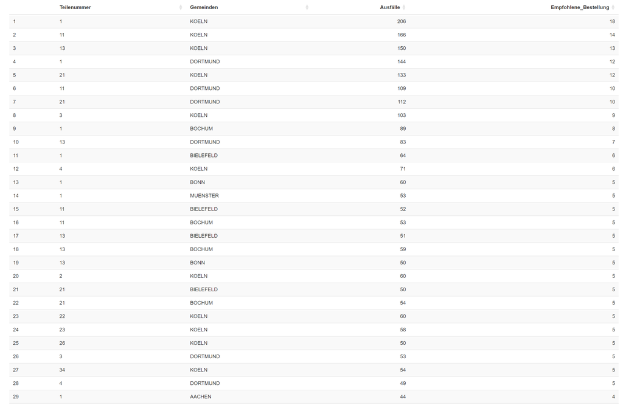

*Abbildung 10: Empfohlene Ersatzteilmengen für jede Stadt*

Diese Mengen sollen sicherstellen, dass in den Werkstätten ausreichend Ersatzteile verfügbar sind, um Fahrzeugausfälle effizient zu beheben.